# Χριστοδουλου Χρηστος 5392 Ασκηση-2

# Ερωτηση 1

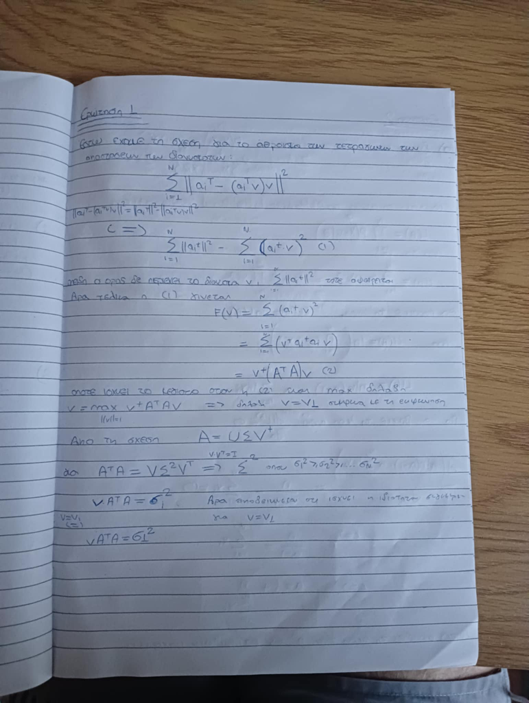

# Ερωτηση 2

**A**

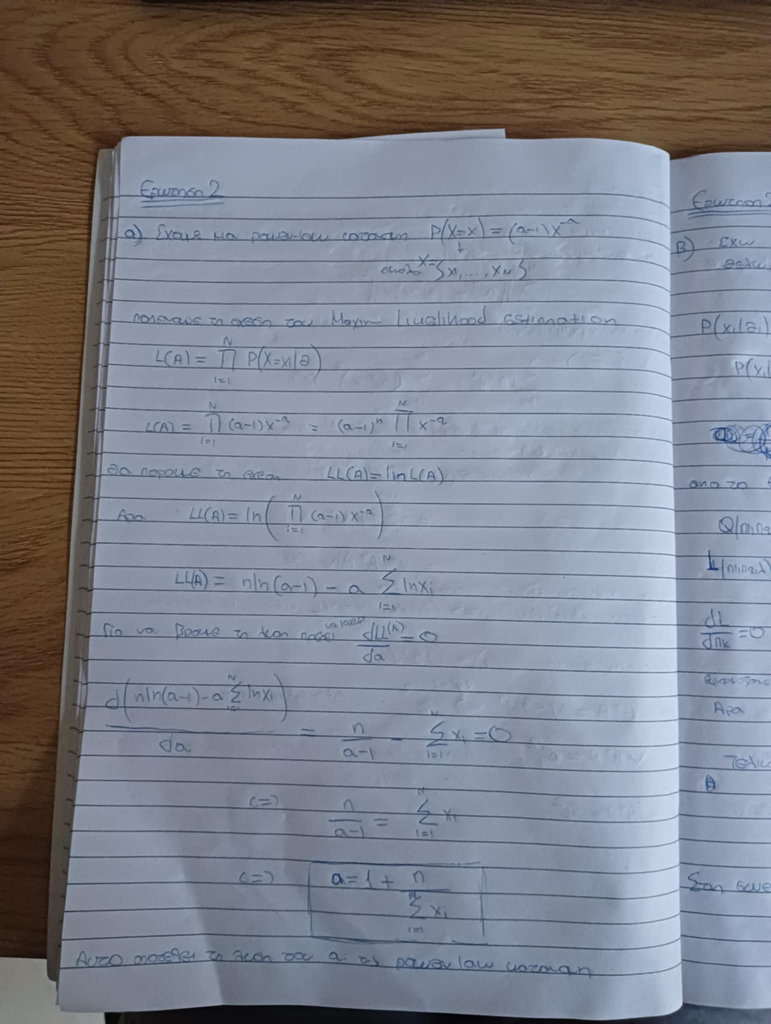

**B**

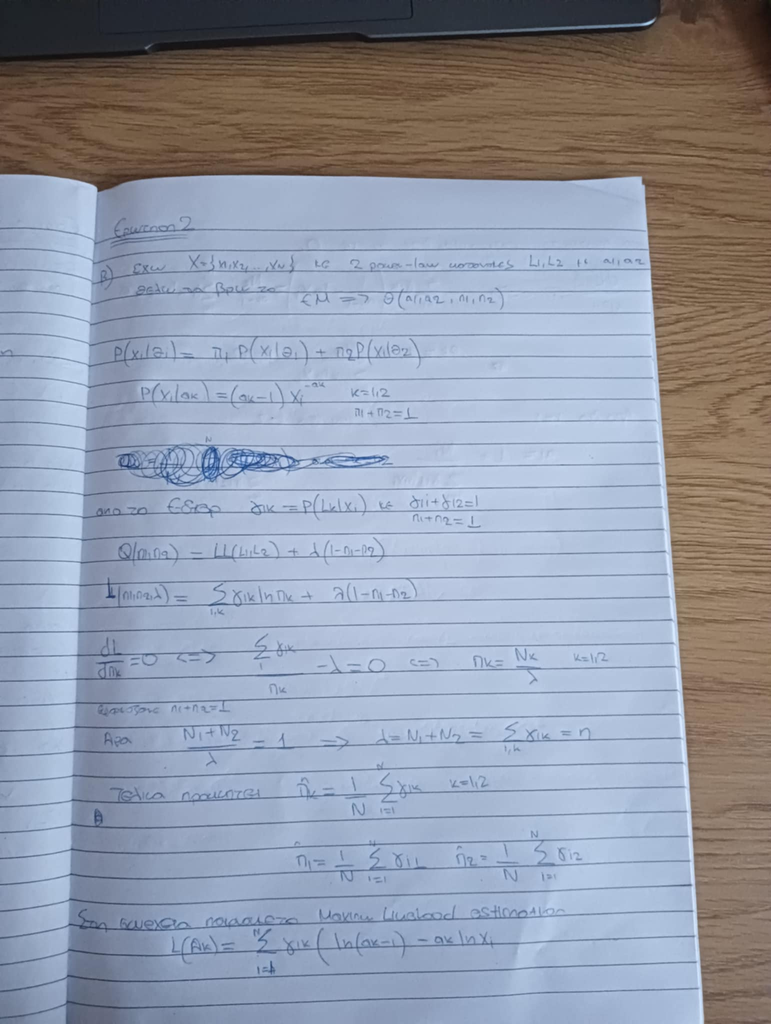

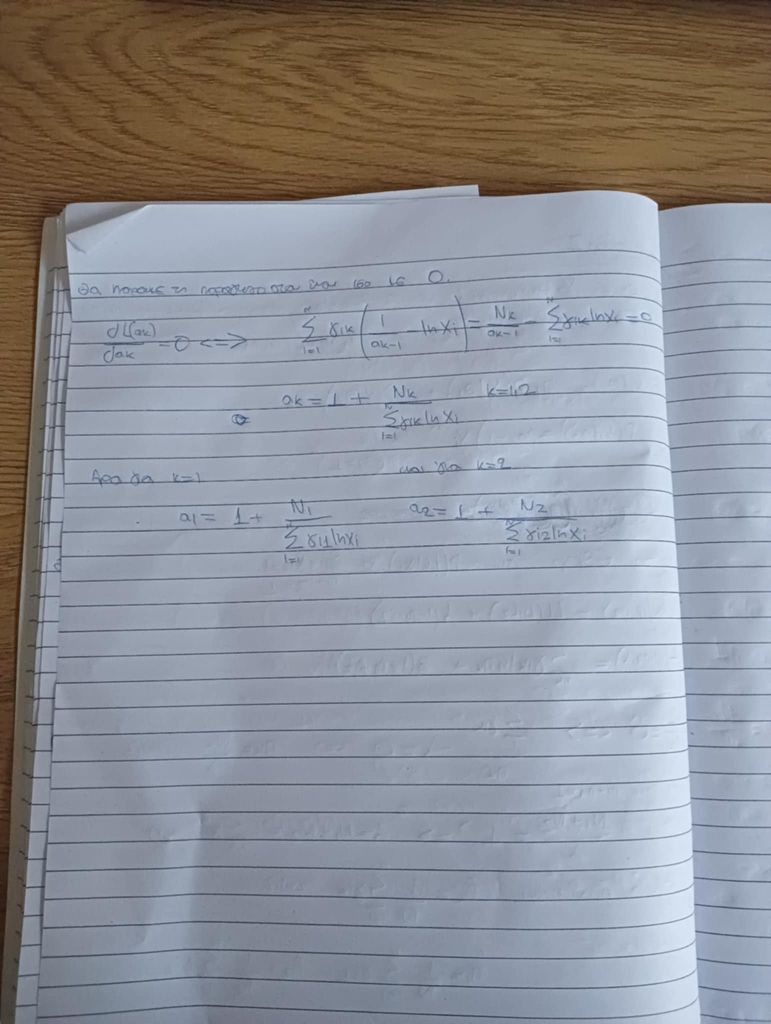

# Ερωτηση 3

Βημα-1

```python
import pandas as pd
import numpy as np
from sklearn.metrics import mean_squared_error


train_data = pd.read_csv("data_train.csv")
test_data = pd.read_csv("data_test.csv")

#calc the mean
user_avg_train = train_data.groupby("uid")["rating"].mean()
item_avg_train = train_data.groupby("mid")["rating"].mean()


mean_nan = train_data['rating'].mean()

#fill the nan with the global mean
test_data['uidpred'] = test_data['uid'].map(user_avg_train).fillna(mean_nan)
test_data['midpred'] = test_data['mid'].map(item_avg_train).fillna(mean_nan)

#rmse
rmse_ua = np.sqrt(mean_squared_error(test_data['rating'], test_data['uidpred']))
rmse_ia = np.sqrt(mean_squared_error(test_data['rating'], test_data['midpred']))


print(f" user-avg rmse: {rmse_ua:.4f}")
print(f" itm-avg rmse: {rmse_ia:.4f}")
```

```
 user-avg rmse: 0.9613
 itm-avg rmse: 0.9860
```

Βημα-2

```
k=1, RMSE=3.1693
k=2, RMSE=3.0719
k=3, RMSE=3.0101
k=4, RMSE=2.9804
k=5, RMSE=2.9613
k=6, RMSE=2.9424
k=7, RMSE=2.9221
k=8, RMSE=2.9231
k=9, RMSE=2.9179
k=10, RMSE=2.9219
k=11, RMSE=2.9156
k=12, RMSE=2.9226
k=13, RMSE=2.9159
k=14, RMSE=2.9103
k=15, RMSE=2.9087
k=16, RMSE=2.9172
k=17, RMSE=2.9228
k=18, RMSE=2.9271
k=19, RMSE=2.9327
k=20, RMSE=2.9360
scd min res is 2.9087 at k=15
```

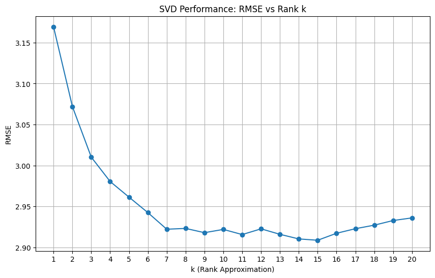

```python
import numpy as np
import pandas as pd
from scipy.sparse import csr_matrix
from scipy.sparse.linalg import svds
from sklearn.metrics import mean_squared_error
import matplotlib.pyplot as plt

#we take the number of users,movies
#+1 is for the 0-indexing

n_users =max(train_data['uid'].max(), test_data['uid'].max()) + 1
n_items =max(train_data['mid'].max(), test_data['mid'].max()) + 1

#sparce r matrix
R_sparse =csr_matrix((train_data['rating'], (train_data['uid'], train_data['mid'])),shape=(n_users, n_items))



K =20
u, s,vt=svds(R_sparse,k=K)


#reverse the u,v,S
u = u[:, ::-1]
s =s[::-1]
vt = vt[::-1, :]

#create to numpy-array from Df

test_uids = test_data['uid'].values
test_mids = test_data['mid'].values
test_ratings = test_data['rating'].values

rmse_results =[]  #hold every rmse-value for every k

#range of k[1,20]
k_values =range(1,K+1)


for k in k_values:

    #k- item slicing

    Uk = u[:, :k]
    Sk = s[:k]
    Vtk = vt[:k, :]


    mul_tmp = Uk * Sk  #multiply of matrixs


    user= mul_tmp[test_uids, :]


    items=Vtk[:, test_mids].T  #do a transpose of the v-matrix

    #final mul (US)*(V.T)
    preds=np.sum(user*items,axis=1)

    # clip to 0<x<5
    preds=np.clip(preds,0,5)

    #rmse
    rmse = np.sqrt(mean_squared_error(test_ratings,preds))
    rmse_results.append(rmse)
    print(f"k={k}, RMSE={rmse:.4f}")


min_rmse = min(rmse_results)

bestk = k_values[rmse_results.index(min_rmse)] #get the index of the min in results-table

print(f"scd min res is {min_rmse:.4f} at k={bestk}")


# Plotting
plt.figure(figsize=(10, 6))
plt.plot(k_values, rmse_results, marker='o', linestyle='-')
plt.title('SVD Performance: RMSE vs Rank k')
plt.xlabel('k (Rank Approximation)')
plt.ylabel('RMSE')
plt.xticks(k_values)
plt.grid(True)
plt.show()
```

Βημα-4

4.1

```python
import numpy as np
import scipy.sparse as sp
from scipy.sparse.linalg import norm


def user_mean(R, u):  #mean rating of a user

    user_row = R[u, :]
    if user_row.nnz == 0:   #if we have nonzeoro-rows we retun 0
        return 0.0
    return np.mean(user_row.data)


def item_users(R, m):

    return R[:, m].nonzero()[0] #return users-uid that rated the m-movie


def similar_users(R, u, m_users, k):


    user_vec = R[u, :]
    user_matrix= R[m_users, :]

    dot_products=user_matrix.dot(user_vec.T).toarray().flatten() #trapnpose make it oto 1d array

    norm_uid =norm(user_vec)  #get the norm for the cosine similar

    norms_candidates =norm(user_matrix, axis=1)
    denominators = norm_uid* norms_candidates


    similarities =np.zeros_like(dot_products)  #calculate to eswteriko ginomeno tou norm_u * norms_candidates

    valid_idx = denominators > 0  #avoid division by 0

    similarities[valid_idx] = dot_products[valid_idx] / denominators[valid_idx]


    sorted_indices = np.argsort(similarities)[-k:][::-1]

    top_k_users = m_users[sorted_indices]

    top_k_sims = similarities[sorted_indices]

    #retunr the uid,cosine-similar

    return top_k_users, top_k_sims


#caluclate the type at step-4 p(u,m)--fro the ucf

def compute_score(k_ratings, k_similarities):

    numerator = np.dot(k_similarities,k_ratings)

    denominator = np.sum(np.abs(k_similarities))

    if denominator == 0: #avoid division by 0
        return 0.0

    return numerator / denominator
```

4.2

```
k=1, RMSE=1.2267
k=2, RMSE=1.0821
k=3, RMSE=1.0366
k=5, RMSE=0.9999
k=10, RMSE=0.9770
k=20, RMSE=0.9712
k=30, RMSE=0.9700
k=40, RMSE=0.9706
k=50, RMSE=0.9708
k=60, RMSE=0.9712
k=70, RMSE=0.9711
k=80, RMSE=0.9712
k=90, RMSE=0.9715
k=100, RMSE=0.9717
Elapsed time: 291.19 seconds
Minimum RMSE: 0.9700 achieved at k=30
```

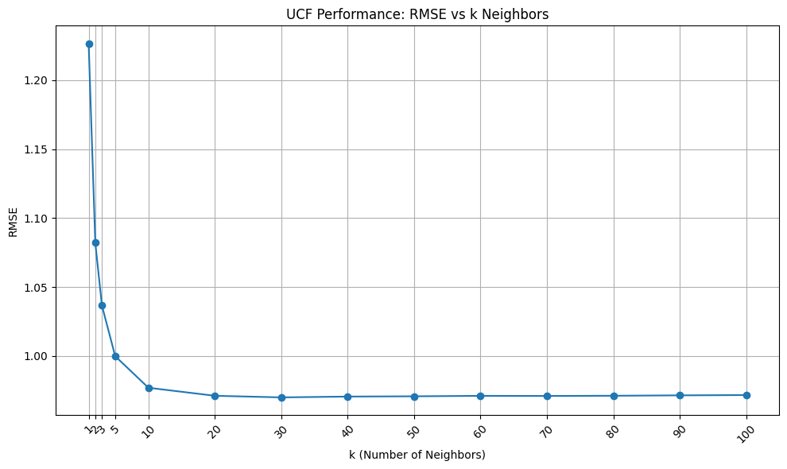

```python
import numpy as np
import matplotlib.pyplot as plt
from sklearn.metrics import mean_squared_error
import math
import time

def predict_ucf(u, m, k):

    raters=item_users(R_sparse, m)  #calculate the uid that rated the m-movie

    if raters.size == 0:
        return user_mean(R_sparse, u)  #if is 0 then return the mean

    k_users,k_sims=similar_users(R_sparse,u,raters,k)   #krataei ta kalytera users me vasi to k-neighbors

    k_ratings =R_sparse[k_users, m].toarray().flatten() #convert to numpy-array all the rating

    prediction =compute_score(k_ratings, k_sims)  #ypologise to to typo me vasi to ucf gia to score
    return prediction


test_data_numpy = test_data.values  #numpy-array all the test set

#test the predict_ucf

k_values = [1,2,3,5,10,20,30,40,50,60,70,80,90,100]

rmse_results =[]

start = time.time()  #start the process

for k in k_values:

    predictions =[]
    actual_ratings =[]


    for i in range(len(test_data_numpy)):

        u = int(test_data_numpy[i, 0])   #1-stili ta u

        m = int(test_data_numpy[i, 1])  #2-stili ta m
        true_r = test_data_numpy[i, 2]  #3 ta rating

        pred = predict_ucf(u,m,k)

        predictions.append(pred) #preds

        actual_ratings.append(true_r)  #pragmatika ratings

    #rmse
    mse = mean_squared_error(actual_ratings, predictions)
    rmse = math.sqrt(mse)

    rmse_results.append(rmse)
    print(f"k={k}, RMSE={rmse:.4f}")



end = time.time()
elapsed = end - start

print(f"Elapsed time: {elapsed:.2f} seconds")

#get the min-rmse from the list
min_rmse = min(rmse_results)
best_k = k_values[rmse_results.index(min_rmse)]


print(f"Minimum RMSE: {min_rmse:.4f} achieved at k={best_k}")



plt.figure(figsize=(10, 6))
plt.plot(k_values, rmse_results, marker='o', linestyle='-')
plt.title('UCF Performance: RMSE vs k Neighbors')
plt.xlabel('k (Number of Neighbors)')
plt.ylabel('RMSE')
plt.grid(True)
plt.xticks(k_values, rotation=45)
plt.tight_layout()
plt.show()
```

4.3

```python
import numpy as np
import math
from sklearn.metrics import mean_squared_error
import time

def predict_ucf_list(u,m,k_list):

    max_k = max(k_list)
    raters = item_users(R_sparse, m)

    if raters.size == 0:
        mean_val = user_mean(R_sparse, u)
        return {k: mean_val for k in k_list}

    #only one time for the max
    top_users, top_sims = similar_users(R_sparse, u, raters, max_k)

    top_ratings = R_sparse[top_users, m].toarray().flatten()  #rsting to uids

    predictions = {}


    for k in k_list:
        if k > len(top_users):  #an einai pare ayti ti timi mono
            current_sims = top_sims
            current_ratings = top_ratings
        else:
          #slicing for the k
            current_sims = top_sims[:k]
            current_ratings = top_ratings[:k]

        predictions[k] = compute_score(current_ratings, current_sims)

    return predictions  #ypologise ta preds

#test loop
k_values = [1, 2, 3, 5, 10, 20, 30, 40, 50, 60, 70, 80, 90, 100]


test_data_numpy = test_data.values #numpy-array


all_preds_new = {k: [] for k in k_values} #for preds

all_actuals_new = [] #for the test-ratings


start=time.time() #start

for i in range(len(test_data_numpy)):

    u = int(test_data_numpy[i, 0])  #1-stili uid
    m = int(test_data_numpy[i, 1])  #2 stuili mid
    true_r = test_data_numpy[i, 2] #3-actula-ratings

    all_actuals_new.append(true_r) #prosthesa edw


    preds_dict = predict_ucf_list(u, m, k_values)


    for k in k_values:
        all_preds_new[k].append(preds_dict[k])


rmse_results =[]


for k in k_values:
    # rmse
    mse = mean_squared_error(all_actuals_new, all_preds_new[k])

    # do the sqrt
    current_rmse = math.sqrt(mse)
    rmse_results.append(current_rmse)
    print(f"k={k:<3} | RMSE={current_rmse:.4f}")

end=time.time()
elapsed = end - start
print(f"Elapsed time: {elapsed:.2f} seconds")

#ypologise to min

min_rmse_val = min(rmse_results)
best_k_index = rmse_results.index(min_rmse_val)
best_k_val = k_values[best_k_index]

print(f"Best k: {best_k_val} with RMSE: {min_rmse_val:.4f}")
```

```
k=1   | RMSE=1.2267
k=2   | RMSE=1.0821
k=3   | RMSE=1.0366
k=5   | RMSE=0.9999
k=10  | RMSE=0.9770
k=20  | RMSE=0.9712
k=30  | RMSE=0.9700
k=40  | RMSE=0.9706
k=50  | RMSE=0.9708
k=60  | RMSE=0.9712
k=70  | RMSE=0.9711
k=80  | RMSE=0.9712
k=90  | RMSE=0.9715
k=100 | RMSE=0.9717
Elapsed time: 24.24 seconds
Best k: 30 with RMSE: 0.9700
```

Παρατηρουμε λοιπον οτι με την υλοποιηση του γρηγορου αλγοριθμου του UCF οτι ο χρονος απο οταν βαζουμε την λιστα σαν ορισμα , σε συγκριση με το καθε k-value σαν ορισμα οτι μειωνεται σε ενα τεραστιο σημαντικο ποσοστο . Ο αλγοριθμος στην 4.2 αφου υπολογιζει για καθε τιμη του κ καθε συναρτηση εχει time=291.19 seconds σε συγκριση με το αλγοριθμο στο ερωτημα 4.3 ο οποιος επεοδη υπολογιζει μονο για το μεγιστο στοιχειο του κ μια φορα απο αυτεσ τις πραξεις τοτε τελειωνει σε time=24.24 seconds λογω των λιγοτερων πραξεων πολλ/σμων και κλησεων των συναρτησεων απο το 4.1 .Εκτος απο αυτο εχουμε τα ιδια αποτελεσματα για καθε τιημ του k για το rmse αλλα και συγκεκριμενα μετα την βελτιστη τιμη του κ=30 οτι ο αλγοριθμος κανει underfitting και αυξανεται το rmse, λογω των περισσοτερων γειτονων κ οι οποιο ειναι ανομοιοι μεταξυ τους.

Βημα-5

| algorithm | best k-param | Best RMSE |
| --- | --- | --- |
| **User Average (UA)** | - | **0.9613** |
| **Item Average (IA)** | - | 0.9860 |
| **SVD (Rank-k)** | k=15 | 2.9087 |
| **User CF (Linear)** | k=30 | 0.9700 |
| **User CF (List)** | k=30 | 0.9700 |

### Σχολιασμός Αποτελεσμάτων

Από τη συγκριτική μελέτη των παραπάνω μεθόδων προκύπτουν τα εξής συμπεράσματα:

Από το Βήμα 1, κατά τον οποίο υλοποιήσαμε τον αλγόριθμο User-Avg και πήραμε το mean των βαθμολογιών κάθε χρήστη, επιστράφηκε RMSE ίσο με 0.9613, το οποίο είναι το μικρότερο σε σχέση με όλους τους υπόλοιπους αλγορίθμους που εξετάσαμε.Αντίθετα, στο Βήμα 2 με τη χρήση του SVD παρατηρήσαμε το υψηλότερο σφάλμα, φτάνοντας στο 2.9087 για k=15 και αυτο λογω οτι πραξεις γινονται σε αραιους πινακες οι οποιες με το πολλα μηδενικα εκλαμβανονται σαν Nan τιμες και φαινεται αυτη η αυξηση του βελτιστου rmse και την παρατηρηση του φαινομενου του underfitting για οσο το κ ξεπερναει το 15.Σχετικά με τον αλγόριθμο User CF, τόσο στην Linear όσο και στην Vectorized υλοποίησή του, τα αποτελέσματα ταυτίζονται, καθώς και στις δύο περιπτώσεις η βέλτιστη επίδοση επιτεύχθηκε για k=30 γείτονες με τιμή RMSE ίση με 0.9700 με την μονη διαφορα τους αποτελει την υλοποιηση τους και το χρονο εκτελεσης.

Το γεγονός ότι ο απλός μέσος όρος του χρήστη (User Average) υπερέχει των υπολοίπων υποδηλώνει ότι στο συγκεκριμένο σύνολο δεδομένων, το rating του καθε uid αποτελεί την πιο ισχυρή πληροφορία. Αντίθετα, η μεγάλη απόκλιση του SVD οφείλεται στην εφαρμογή της παραγοντοποίησης στον αραιό πίνακα, όπου οι βαθμολογίες που έλειπαν θεωρήθηκαν μηδενικές, στρεβλώνοντας τις προβλέψεις προς τα κάτω. Τέλος, η ταύτιση των αποτελεσμάτων μεταξύ Linear και Vectorized UCF επιβεβαιώνει ότι η διανυσματική υλοποίηση βελτιώνει δραματικά τον χρόνο εκτέλεσης χωρίς να επηρεάζει την μαθηματική ακρίβεια του αλγορίθμου.

# Bonus-1

```python
import numpy as np
from sklearn.metrics import mean_squared_error

def predict_ucf_mean_centered(u, m, k):

    mu_u = user_mean(R_sparse, u)

    raters = item_users(R_sparse, m)

    if len(raters) == 0:
        return mu_u

    users,sims =similar_users(R_sparse, u, raters, k)

    ratings = R_sparse[users, m].toarray().ravel()  #kratame ta ratings apo to pinaka poy ginetai se 1d numpy-array

    mu_neighbors = np.array([user_mean(R_sparse, v) for v in users])  #krata to mean gia xristi v poy vrisketai sti lista users san numpy-array

    centered = ratings-mu_neighbors  #substract of mean for uid

    deviation = compute_score(centered,sims)

    return np.clip(mu_u + deviation, 0, 5)



k_values = [1,2,3,5,10,20,30,40,50,60,70,80,90,100]

test_np = test_data.values   #metatropi se df

true_ratings = test_np[:, 2]  #kratame mono ti 3stili twn ratings apo to test-data

rmse_results =[]

for k in k_values:

    predictions = [
        predict_ucf_mean_centered(int(row[0]), int(row[1]), k)  #get the row[0]--uid  kai row[1]--mid
        for row in test_np
    ]

    rmse = np.sqrt(mean_squared_error(true_ratings, predictions))
    rmse_results.append(rmse)

    print(f"k= {k:<3} | RMSE={rmse:.4f}")

best_rmse = min(rmse_results)
best_idx = rmse_results.index(best_rmse)
best_k = k_values[best_idx]

print(f"\nBest k mean-ucf : {best_k} | rmse= {best_rmse:.4f}")
```

```
k= 1   | RMSE=1.1227
k= 2   | RMSE=1.0043
k= 3   | RMSE=0.9641
k= 5   | RMSE=0.9333
k= 10  | RMSE=0.9124
k= 20  | RMSE=0.9065
k= 30  | RMSE=0.9057
k= 40  | RMSE=0.9064
k= 50  | RMSE=0.9067
k= 60  | RMSE=0.9070
k= 70  | RMSE=0.9069
k= 80  | RMSE=0.9069
k= 90  | RMSE=0.9073
k= 100 | RMSE=0.9075

Best k mean-ucf : 30 | rmse= 0.9057
```

| algorithm | best k-param | Best RMSE |
| --- | --- | --- |
| **User CF (substract-mean)** | k=30 | 0.9057 |

Παρατηρούμε, λοιπόν, σε σύγκριση με τις προηγούμενες υλοποιήσεις, ότι με τη συγκεκριμένη προσέγγιση επιτυγχάνεται το μικρότερο RMSE σε σχέση με όλους τους προηγούμενους αλγορίθμους. Συγκεκριμένα, για κάθε χρήστη (uid) υπολογίζεται ο μέσος όρος των αξιολογήσεών του (μ) και αφαιρείται από το αντίστοιχο rating. Στη συνέχεια, με βάση αυτό το κανονικοποιημένο rating, εφαρμόζεται κανονικά ο απλός αλγόριθμος UCF. Το τελικό rating προκύπτει προσθέτοντας στην πρόβλεψη του UCF τον μέσο όρο ανά χρήστη (uid) που είχε αφαιρεθεί προηγουμένως.Τέλος, η βέλτιστη τιμή του k ως προς το RMSE παραμένει ίδια σε σχέση με τις προηγούμενες υλοποιήσεις UCF-linear και UCF-list. Ωστόσο, παρατηρείται φαινόμενο υποβάθμισης της απόδοσης για τιμές k > 30, λόγω της αυξημένης επίδρασης του θορύβου και της συμμετοχής ανομοίων χρηστών (uids) στον υπολογισμό της πρόβλεψης.